# Statistical inference with the GSS data

## Setup

### Load packages

We shall explore the data using the `dplyr` package and visualize it using the `ggplot2` package for data visualization.

Let’s load the packages.

```r
library(ggplot2)
library(dplyr)
library(statsr)
```

### Load data

GSS Dataset:

For more than four decades, the General Social Survey (GSS) has been monitoring societal change and has studied the growing complexity of American society. It is the only full-probability, personal-interview survey designed to monitor changes in both social characteristics and attitudes currently being conducted in the United States.

gss.Rdata is loaded into RStudio from the same file folder as where the RmD file is placed.

```r
load("gss.Rdata")

summary(gss$coninc)
```

```
##    Min. 1st Qu.  Median    Mean 3rd Qu.    Max.    NA's
##     383   18440   35600   44500   59540  180400    5829
```

## Part 1: Data

The basic purpose of the GSS is to gather information about contemporary American society in order to explain trends in attitudes and behaviours.

GSS Data was collected in a survey, using random sampling method. The Surveys was conducted in US households from a scientific random sample designed to represent a cross-section of the country. The random selection of households from across the United States ensures that the results of the survey are scientifically valid. All households from across the country had an equal chance of being selected for this survey. And their opinions cannot be replaced by anyone else!

As this data is collected by surveys, it is observational data, and not experimental data.

This data can be used to make inferences or relations among variables by identifying the explanatory and response variables. so, only generalized conclusions can be made, not causations.

There is no Random Assignment here, as it happens only with Experiments, where people are mandated into treatment and control groups. Whereas GSS is a survey and there is no compulsion about attending the survey.

## Part 2: Research question

In this research, we are going to infer how the various income classes of US think about spending on one of the National Problems. Among the employed class in US, let us try to understand how the different income classes feel about spending on ‘Improving Nations Education System’.

Prior to that let us also understand how the educational qualification of people decide the income class, which in turn influences people’s opinion on Improving Nations Education System. Let us study the ‘coninc’ variable that contains ‘FAMILY INCOME IN CONSTANT DOLLARS’

```r
summary(gss$coninc)
```

```
##    Min. 1st Qu.  Median    Mean 3rd Qu.    Max.    NA's
##     383   18440   35600   44500   59540  180400    5829
```

Let us categorise this income data based on Min, Q1, Median, Q3 and Max values.

Income Range Income class 0 - 18440 Low 18441 - 35600 Medium 35601 - 59540 High 59541 - 180400 VeryHigh

We have to create a new categorical variable ‘incomeclass’ using mutate command, with 4 categorical levels that relate to the income range identified above

```r
#Removes NA from interest variables
gss_NA <- gss[!(is.na(gss$coninc)|is.na(gss$nateduc)),]

#create inclass variable
gss_NA$inclass=as.factor(ifelse((gss_NA$coninc > 0) & (gss_NA$coninc <= 18440), "Low", ifelse((gss_NA$coninc >= 18441) & (gss_NA$coninc <= 35600), "Medium",ifelse((gss_NA$coninc >= 35601) & (gss_NA$coninc <= 59540),"High","VeryHigh"))))

#verify the new income classes created
unique(gss_NA$inclass)
```

```
## [1] High     Medium   Low      VeryHigh
## Levels: High Low Medium VeryHigh
```

```r
#verify the NA free nateduc variable
unique(gss_NA$nateduc)
```

```
## [1] Too Little  About Right Too Much
## Levels: Too Little About Right Too Much
```

Let us identify the explanatory and Response variables involved in the analysis

Response variable: “nateduc” (‘Improving Nations Education System’) variable type: categorical 3 levels (“TOO LITTLE”, “ABOUT RIGHT”, “TOO MUCH”)

## Part 3: Exploratory data analysis

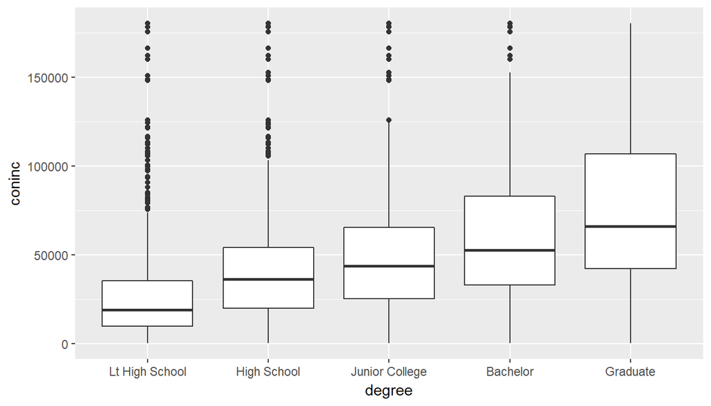

```r
ggplot(gss_NA[!is.na(gss_NA$degree),], aes(x=degree, y=coninc)) + geom_boxplot()
```

It shows that people with Higher educational qualification have got higher income, though there are notable outliers with high income in Lt High School and High School group.

So, it is obvious that Education is directly proportional to income, which is visually observed in the box plot’s (income) range for each educational qualification.

As the income is strongly influenced by degree, let us understand how the various income class thinks about Improving Nations Education System. Let us check how related are the income class ‘inclass’ identified above and their opinion on Improving Nations Education System.

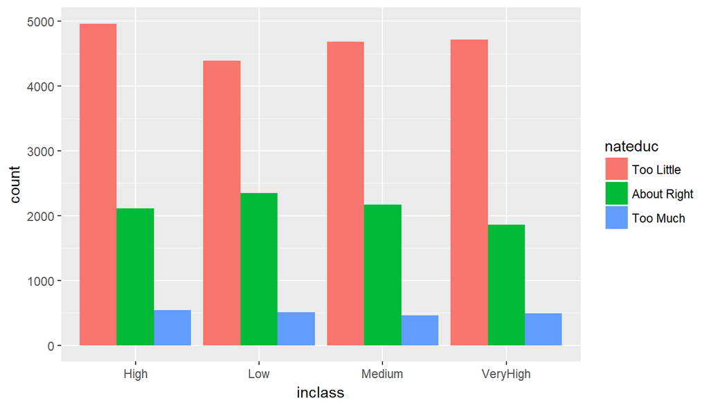

```r
ggplot(data = gss_NA, aes(x=inclass)) + geom_bar(aes(fill = nateduc), position = "dodge")
```